# Problem Set 11

# *Exercise 11.2*

## *part a)*

#### Is it reasonable to use ANOVA?

#### Read in data and get an overview

```r
library(tidyverse)
```

```r
yt <- read_csv("rusty_bolt.csv")
```

```r
summary(yt)
```

```
##   treatment             torque
##  Length:28          Min.   : 87.1
##  Class :character   1st Qu.:108.0
##  Mode  :character   Median :120.5
##                     Mean   :117.8
##                     3rd Qu.:129.4
##                     Max.   :140.8
```

#### Exploratory Analysis

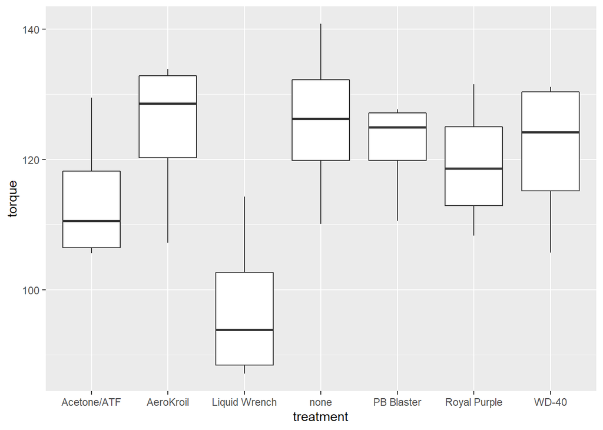

```r
ggplot(yt, aes(treatment, torque)) + geom_boxplot()
```

#### Get metrics for the groups

```r
yt %>%
  group_by(treatment) %>%
  summarise(n = n(),
            mean = mean(torque),
            sd = sd(torque))
```

```
## # A tibble: 7 x 4
##   treatment         n  mean    sd
##   <chr>         <int> <dbl> <dbl>
## 1 Acetone/ATF       4 114.  11.0
## 2 AeroKroil         4 125.  12.3
## 3 Liquid Wrench     4  97.3 12.5
## 4 none              4 126.  12.8
## 5 PB Blaster        4 122.   7.90
## 6 Royal Purple      4 119.  10.1
## 7 WD-40             4 121.  11.9
```

#### To answer the question of whether it is reasonable to apply ANOVA in this case, we need to understand what ANOVA is used for and if it could be used in this case. ANOVA is used to assess whether the mean of the outcome variable is different for different levels of a categorical variable. So in this case we want to see if the mean of the torque is different for different levels of treatment. Now we just need to check the conditions:

#### 1) The observations should be independent within and between groups: There is no mention that the sample was a random sample hence this condition can’t be checked and we are going to have to make assumptions if we wanna use ANOVA.

#### 2) The observations within each group should be nearly normal: This is especially important when the sample sizes are small like in this case, where we only have 4 samples for each treatment. As we can see from the graph below made by the autoplot() function, the points are relatively close to the line, but not all, hence deciding if its nearly normal is pretty subjective. I would say that it doesn’t satisfy the condition 100% especially due to the low sample size. One would expect the points to be closer for such a small sample to be sure and more intricate about the distribution.

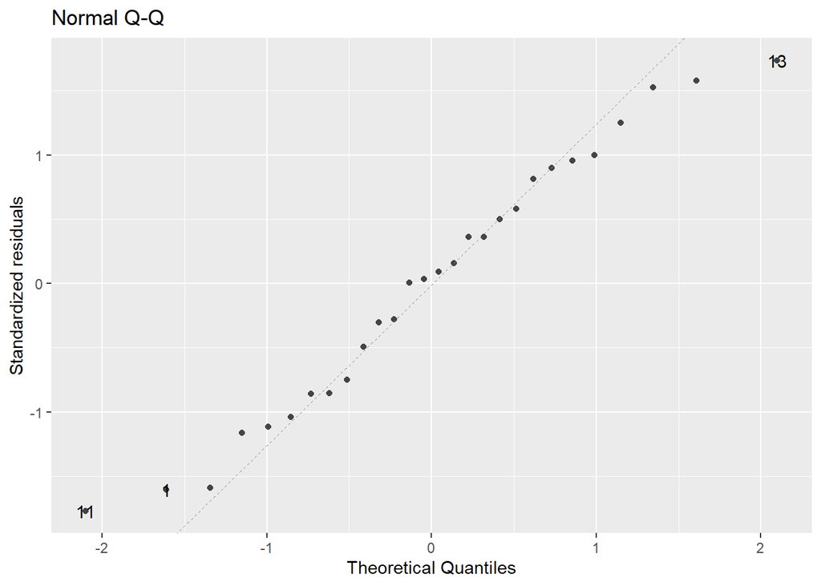

```r
library(ggfortify)
autoplot(aov(torque ~ treatment, data = yt), which = 2, ncol = 1)
```

#### 3) The variability across the groups should be about equal: This is especially important when the sample sizes differ between groups. However, here all have the same size (it is rather small though). As seen by the boxplot above, the variability for “PB Blaster” seems smaller than the others, and the whiskers are also quite different for some of the treatment levels, however with such a small sample size of 4, it is difficult to judge and say that they really are different. Therefore we would continue with the analysis but we have to be critical and meticulous. One could explain the variability by saying that a certain group was under/overestimated with this small sample size.

## *part b)*

#### Hypotheses and conducting test in R with conclusion

#### Hypotheses:

$Ho$ : $\mu_1 = \mu_2 = \mu_3= \mu_4= \mu_5= \mu_6 = \mu_7$ : The mean outcome of torque is same across all treatment categories (each number represents a different treatment group)

$HA$ : At least one mean is different than the others.

#### ANOVA test regardless of conditions

```r
yt_anova <- aov(torque ~ treatment, data = yt)
summary(yt_anova)
```

```
##             Df Sum Sq Mean Sq F value Pr(>F)
## treatment    6   2312   385.3   3.005  0.028 *
## Residuals   21   2693   128.2
## ---
## Signif. codes:  0 '***' 0.001 '**' 0.01 '*' 0.05 '.' 0.1 ' ' 1
```

Conclusion: The p value is fairly small, however no significance level was given (with a 5% significance level for example, we would reject the null hypotheses indicating that at least 1 mean is different than the others)

## *part c)*

#### Already disscused in part (a) in the 3rd condition

## *part d)*

#### Tukey’s honestly significant difference test

#### post-hoc analysis

```r
tukey <- TukeyHSD(yt_anova)
tukey
```

```
##   Tukey multiple comparisons of means
##     95% family-wise confidence level
##
## Fit: aov(formula = torque ~ treatment, data = yt)
##
## $treatment
##                               diff        lwr       upr     p adj
## AeroKroil-Acetone/ATF       10.500 -15.528871 36.528871 0.8392155
## Liquid Wrench-Acetone/ATF  -16.775 -42.803871  9.253871 0.3905832
## none-Acetone/ATF            11.800 -14.228871 37.828871 0.7564533
## PB Blaster-Acetone/ATF       7.975 -18.053871 34.003871 0.9493275
## Royal Purple-Acetone/ATF     5.200 -20.828871 31.228871 0.9940450
## WD-40-Acetone/ATF            7.250 -18.778871 33.278871 0.9675997
## Liquid Wrench-AeroKroil    -27.275 -53.303871 -1.246129 0.0360682
## none-AeroKroil               1.300 -24.728871 27.328871 0.9999980
## PB Blaster-AeroKroil        -2.525 -28.553871 23.503871 0.9998992
## Royal Purple-AeroKroil      -5.300 -31.328871 20.728871 0.9934082
## WD-40-AeroKroil             -3.250 -29.278871 22.778871 0.9995651
## none-Liquid Wrench          28.575   2.546129 54.603871 0.0254618
## PB Blaster-Liquid Wrench    24.750  -1.278871 50.778871 0.0693050
## Royal Purple-Liquid Wrench  21.975  -4.053871 48.003871 0.1355122
## WD-40-Liquid Wrench         24.025  -2.003871 50.053871 0.0830228
## PB Blaster-none             -3.825 -29.853871 22.203871 0.9989015
## Royal Purple-none           -6.600 -32.628871 19.428871 0.9795396
## WD-40-none                  -4.550 -30.578871 21.478871 0.9971128
## Royal Purple-PB Blaster     -2.775 -28.803871 23.253871 0.9998253
## WD-40-PB Blaster            -0.725 -26.753871 25.303871 0.9999999
## WD-40-Royal Purple           2.050 -23.978871 28.078871 0.9999703
```

#### Conclusion

##### To see which treatments are significantly different from each other, we have to look at the adjusted p-value and choose the ones below our significance level which is 5%. The following list represents those ones:

```r
treatments <- tukey$treatment
lessThanSigLev <- treatments[, "p adj"] < 0.05
which(lessThanSigLev)
```

```
## Liquid Wrench-AeroKroil      none-Liquid Wrench
##                       7                      12
```

##### This suggests that Liquid Wrench-AeroKroil and none-Liquid Wrench have means that are different than each other, because the adjusted p-value for each of the pairs is below the signifance level indicating that the means are different (in favor of alternative). Furthermore one can see that those pairs don’t cover 0 in their interval which means there’s a relatively high chance that they are different from each other aiding to the same conclusion already made.